# An Ensemble Model: Follow-up Prediction for Brain Tumor Patients

DA5030

Zoe Chow

Summer 2025

## Introduction

In this report, we use the [*Brain Tumor Dataset*](https://www.kaggle.com/datasets/miadul/brain-tumor-dataset) (MIT license, Kaggle) to develop an ensemble model that predicts whether a patient requires follow-up treatment based on tumor characteristics and clinical information. The ensemble combines random forests with homogeneous ensembles of logistic regression, neural networks, and k-nearest neighbors (kNN) to capture both linear and nonlinear relationships in the data.

The packages used in this project: `psych`, `dplyr`, `ggplot2`, `kableExtra`, `knitr`, `randomForest`, `caret`, `pROC`, `class`, `FNN`, `nnet`.

## Exploratory Data Analysis (EDA)

Before building the ensemble model to predict whether a patient requires follow-up care, it is important to first explore and understand the dataset. Exploratory Data Analysis (EDA) helps reveal the structure of the data, understand variable distributions, uncover relationships between features, detect potential class imbalances, and identify data quality issues such as missing values or outliers. These insights are essential for informed preprocessing and effective model development.

### Data Structure

|  | Patient_ID | Age | Gender | Tumor_Type | Tumor_Size | Location | Histology | Stage | Symptom_1 | Symptom_2 | Symptom_3 | Radiation_Treatment | Surgery_Performed | Chemotherapy | Survival_Rate | Tumor_Growth_Rate | Family_History | MRI_Result | Follow_Up_Required |
| --- | --- | --- | --- | --- | --- | --- | --- | --- | --- | --- | --- | --- | --- | --- | --- | --- | --- | --- | --- |
| 1 | 1 | 73 | Male | Malignant | 5.375612 | Temporal | Astrocytoma | III | Vision Issues | Seizures | Seizures | No | No | No | 51.31258 | 0.1118756 | No | Positive | Yes |
| 2 | 2 | 26 | Male | Benign | 4.847098 | Parietal | Glioblastoma | II | Headache | Headache | Nausea | Yes | Yes | Yes | 46.37327 | 2.1657356 | Yes | Positive | Yes |
| 3 | 3 | 31 | Male | Benign | 5.588391 | Parietal | Meningioma | I | Vision Issues | Headache | Seizures | No | No | No | 47.07222 | 1.8842278 | No | Negative | No |

```
## 'data.frame':    20000 obs. of  19 variables:
##  $ Patient_ID         : int  1 2 3 4 5 6 7 8 9 10 ...
##  $ Age                : int  73 26 31 29 54 27 72 61 50 54 ...
##  $ Gender             : Factor w/ 2 levels "Female","Male": 2 2 2 2 1 2 2 2 2 2 ...
##  $ Tumor_Type         : Factor w/ 2 levels "Benign","Malignant": 2 1 1 2 1 2 2 1 1 1 ...
##  $ Tumor_Size         : num  5.38 4.85 5.59 1.44 2.42 ...
##  $ Location           : Factor w/ 4 levels "Frontal","Occipital",..: 4 3 3 4 3 1 2 2 4 1 ...
##  $ Histology          : Factor w/ 4 levels "Astrocytoma",..: 1 2 4 3 2 1 4 1 3 4 ...
##  $ Stage              : Factor w/ 4 levels "I","II","III",..: 3 2 1 4 1 1 4 1 4 1 ...
##  $ Symptom_1          : Factor w/ 4 levels "Headache","Nausea",..: 4 1 4 4 1 4 4 1 4 3 ...
##  $ Symptom_2          : Factor w/ 4 levels "Headache","Nausea",..: 3 1 1 3 1 4 1 3 4 4 ...
##  $ Symptom_3          : Factor w/ 4 levels "Headache","Nausea",..: 3 2 3 1 3 1 2 2 2 4 ...
##  $ Radiation_Treatment: Factor w/ 2 levels "No","Yes": 1 2 1 2 1 2 2 2 1 2 ...
##  $ Surgery_Performed  : Factor w/ 2 levels "No","Yes": 1 2 1 1 1 2 1 2 2 1 ...
##  $ Chemotherapy       : Factor w/ 2 levels "No","Yes": 1 2 1 2 2 1 2 1 2 1 ...
##  $ Survival_Rate      : num  51.3 46.4 47.1 51.9 54.7 ...
##  $ Tumor_Growth_Rate  : num  0.112 2.166 1.884 1.283 2.069 ...
##  $ Family_History     : Factor w/ 2 levels "No","Yes": 1 2 1 2 1 1 1 1 1 2 ...
##  $ MRI_Result         : Factor w/ 2 levels "Negative","Positive": 2 2 1 1 2 1 1 1 1 2 ...
##  $ Follow_Up_Required : Factor w/ 2 levels "No","Yes": 2 2 1 1 2 2 1 1 2 2 ...
```

The dataset contains **20,000** observations and **19** variables, including the target variable, `Follow_Up_Required.` The remaining features provide a comprehensive profile of each patient, covering demographic information, tumor characteristics (such as size, type, and stage), presenting symptoms, and treatment history (including surgery, radiation, and chemotherapy). Of the 19 variables, there are **5 numerical features**, **13 categorical features**, and **1 target variable**. The numeric feature `Patient_ID` is an identifier with no analytical meaning. Therefore, we will remove this column before further examining the data, resulting in **18** remaining variables. Additionally, the target and categorical features are stored as factors; these will need to be encoded for models other than random forests.

### Data Distribution

```
##       Age           Gender          Tumor_Type      Tumor_Size
##  Min.   :20.00   Female:10016   Benign   : 9970   Min.   :0.5004
##  1st Qu.:34.00   Male  : 9984   Malignant:10030   1st Qu.:2.8331
##  Median :49.00                                    Median :5.1990
##  Mean   :49.43                                    Mean   :5.2349
##  3rd Qu.:65.00                                    3rd Qu.:7.6266
##  Max.   :79.00                                    Max.   :9.9994
##                                                   NA's   :473
##       Location              Histology    Stage              Symptom_1
##  Frontal  :4925   Astrocytoma    :4937   I  :4986   Headache     :5045
##  Occipital:4967   Glioblastoma   :5068   II :5093   Nausea       :4969
##  Parietal :4990   Medulloblastoma:4979   III:4953   Seizures     :5028
##  Temporal :5118   Meningioma     :5016   IV :4968   Vision Issues:4958
##
##
##
##          Symptom_2            Symptom_3    Radiation_Treatment
##  Headache     :4996   Headache     :4791   No : 9979
##  Nausea       :4931   Nausea       :4867   Yes:10021
##  Seizures     :5054   Seizures     :4893
##  Vision Issues:5019   Vision Issues:4870
##                       NA's         : 579
##
##
##  Surgery_Performed Chemotherapy Survival_Rate    Tumor_Growth_Rate
##  No : 9940         No : 9903    Min.   : 40.00   Min.   :0.1000
##  Yes:10060         Yes:10097    1st Qu.: 55.18   1st Qu.:0.8304
##                                 Median : 70.28   Median :1.5418
##                                 Mean   : 70.11   Mean   :1.5477
##                                 3rd Qu.: 85.04   3rd Qu.:2.2625
##                                 Max.   :100.00   Max.   :2.9998
##                                 NA's   :532
##  Family_History    MRI_Result    Follow_Up_Required
##  No :10002      Negative: 9971   No : 9899
##  Yes: 9998      Positive:10029   Yes:10101
##
##
##
##
##
```

According to the summary statistics, there is no evidence of class imbalance in the target variable. Additionally, the mean and median values of the numeric features are relatively close, suggesting these variables may be symmetric. The categorical features also appear to have relatively balanced class frequencies. These assumptions will be further examined using visualizations of the data distributions.

#### Visualization of Features

The distribution of the target variable (`Follow_Up_Required`), numeric variables, and categorical variables will be examined. The numeric and categorical variables will be split by the classes of the target variable.

##### Target Variable

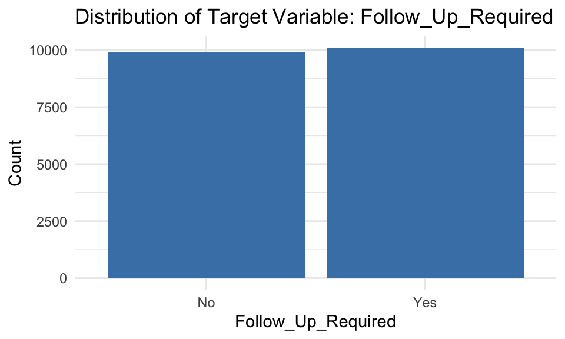

The graph above confirms that there is no class imbalance displayed in the data. If class imbalance were present, *stratified sampling* would be essential during train-test splitting to preserve representative class distributions.

##### Numeric Features

The numeric features of the dataset include `Age`, `Tumor_Size`, `Survival_Rate`, `Tumor_Growth_Rate`. The graphs depict the distribution of each numeric feature according to the class of the predictor.

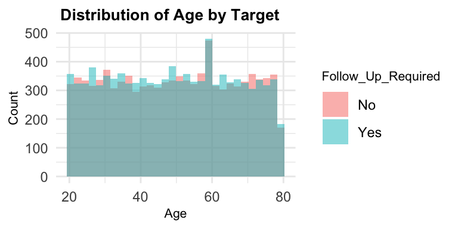

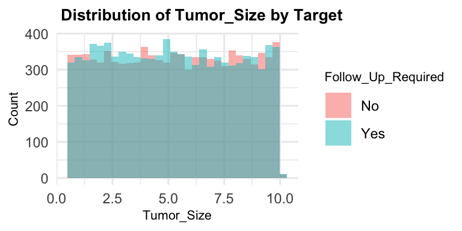

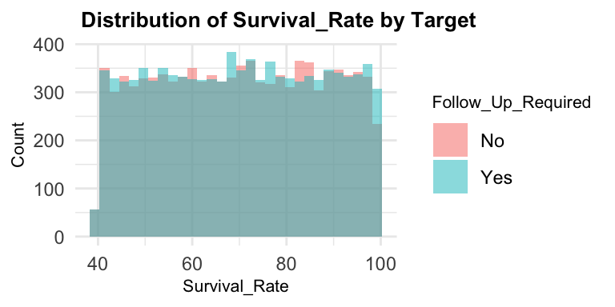

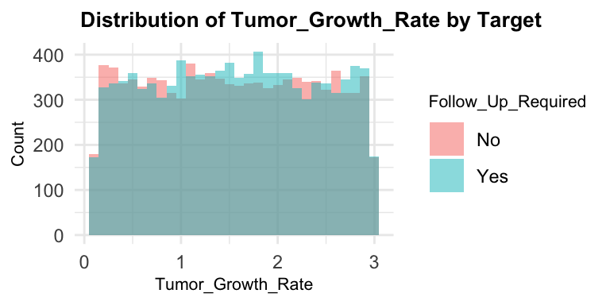

According to the graphs, although the features are not normally distributed, they are relatively symmetric and uniform, indicating that the values are evenly spread as opposed to being concentrated around the mean. As such, it is likely that there are no outliers in the data, however, this will need to be confirmed using the z-score. Log and square root transformations can also will tested to see whether they improve the distribution of the data. Standardization will also be needed for kNN and neural network models.

##### Categorical Features

The categorical features of the data include `Gender`, `Tumor_Type`, `Location`, `Histology`, `Stage`, `Symptom_1`, `Symptom_2`, `Symptom_3`, `Radiation_Treatment`, `Surgery_Performed`, `Chemotherapy`, `Family_History`, `MRI_Result`. The graphs depict the distribution of each categorical feature according to the class of the predictor. Categorical distribution visualization provides insight into proportions, patterns, and imbalances in the data, which will allow for better preprocessing decisions.

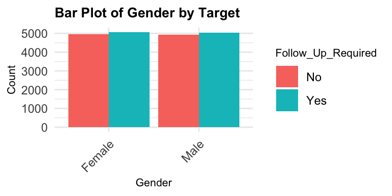

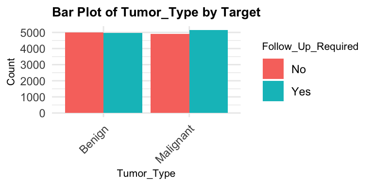

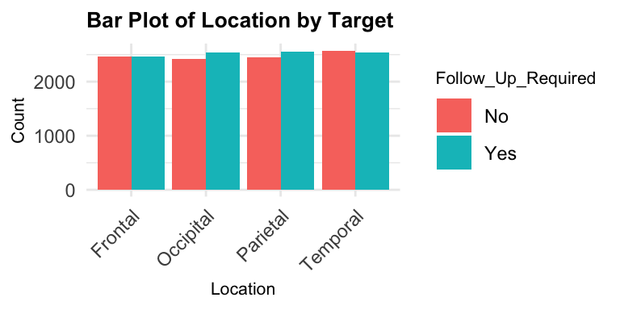

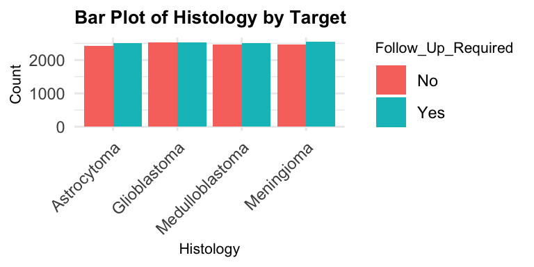

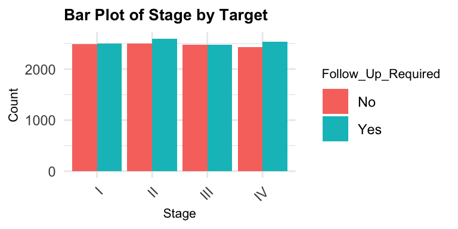

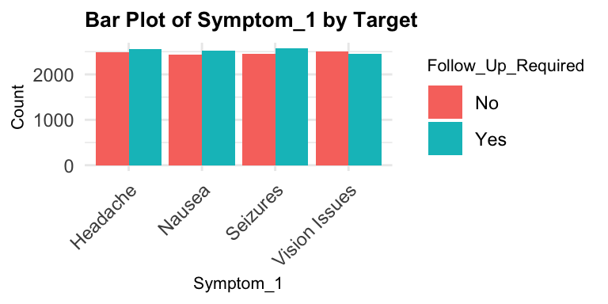

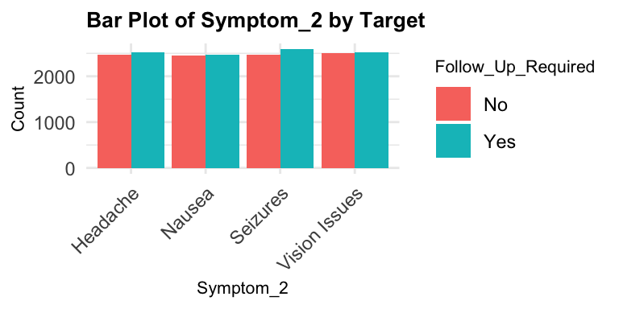

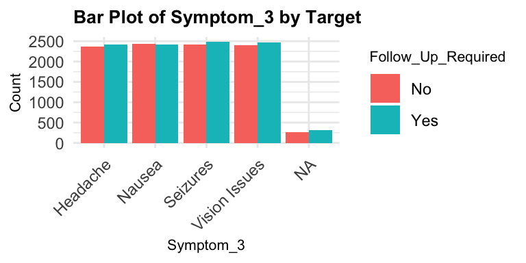

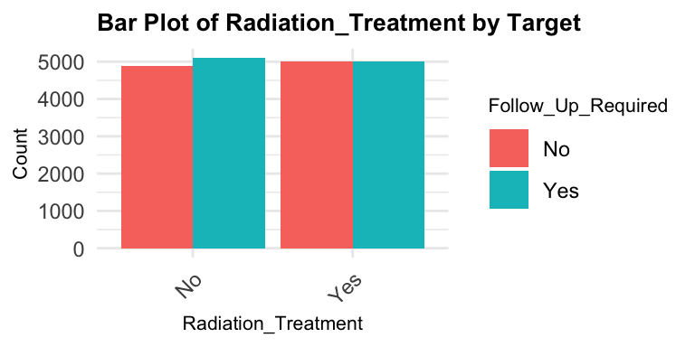

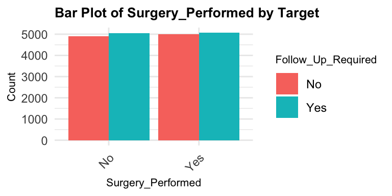

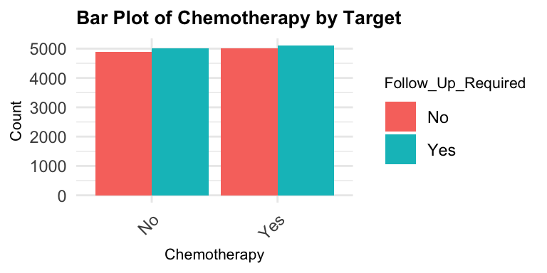

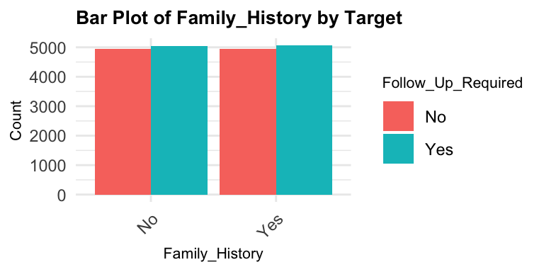

[1 more figures not shown]

The distribution of categorical features is relatively balanced. While `Symptom_3` contains missing values, symptoms 1, 2, and 3 share the same class structure. Rather than imputing the missing values in `Symptom_3` and applying one-hot encoding to each symptom variable separately, I will create binary indicator variables for each symptom class to capture whether the patient previously experienced each specific symptom type. This approach will reduce dimensionality while preserving symptom information and better handling the missing data pattern. Furthermore, I will convert `Stage` to numeric values to maintain its natural ordinality. For features with only 2 classes (`Gender`, `Tumor_Type`, `Radiation_Treatment`, `Surgery_Performed`, `Chemotherapy`, `Family_History`, and `MRI_Results`), I will apply label encoding (0/1). Given the low cardinality of the remaining categorical features (`Location` and `Histology`)—each having 4 classes—I will perform one-hot encoding. This preprocessing approach will be applied to the dataset used for logistic regression, kNN, and neural network models.

### Missing

```r
colSums(is.na(df))
```

```
##                 Age              Gender          Tumor_Type          Tumor_Size
##                   0                   0                   0                 473
##            Location           Histology               Stage           Symptom_1
##                   0                   0                   0                   0
##           Symptom_2           Symptom_3 Radiation_Treatment   Surgery_Performed
##                   0                 579                   0                   0
##        Chemotherapy       Survival_Rate   Tumor_Growth_Rate      Family_History
##                   0                 532                   0                   0
##          MRI_Result  Follow_Up_Required
##                   0                   0
```

Missing data are observed in three features: `Tumor_Size`, `Symptom_3`, and `Survival_Rate`. As mentioned previously, instead of imputing for `Symptom_3`, I will create binary features to represent the symptom classes for all symptom features. As for `Tumor_Size` and `Survival_Rate`, I will impute using grouped statistics from related features. `Tumor_Type`, `Histology`, `Stage`, and `Location` directly determine typical tumor characteristics; therefore, I will impute `Tumor_Size` with either the mean or median based on these grouping features. For `Survival_Rate`, I will use established prognostic factors in oncology—`Tumor_Type`, `Histology`, `Stage`, and `Age`—to impute missing values. The choice between mean and median will be determined based on the presence of outliers. If outliers are prevalent within the groups, I will use the median for robustness.

Although Decision Trees can handle missing data natively through surrogate splits, the function I plan to use for Random Forest (`randomForest()` of the **randomForest** package) does not handle missing data by default. Therefore, I will apply the imputations and binary feature engineering that I mentioned before for all datasets. This will also ensure consistency throughout the different models.

### Outliers

```r
outliers <- function(df) {
  outliers <- c()
  for (col in 1:ncol(df)) {
    m <- mean(df[[col]], na.rm = TRUE)
    s <- sd(df[[col]], na.rm = TRUE)

    # Compute z-scores and find outliers
    z_scores <- abs((df[[col]] - m) / s)
    outlierRows <- which(z_scores > 3.0)

    # append outlier row to a list
    outliers <- c(outliers, outlierRows)

    # Print results
    col_name <- colnames(df)[col]
    if (length(outlierRows) > 0) {
      cat("Found outliers in column '", col_name, "':\n", sep = "")
      cat("   --> ", df[outlierRows,col], "\n\n")
    } else {
      cat("No outliers found in column '", col_name, "'\n", sep = "")
    }
  }

}

outliers <- outliers(df[,numeric_feats])
```

```
## No outliers found in column 'Age'
## No outliers found in column 'Tumor_Size'
## No outliers found in column 'Survival_Rate'
## No outliers found in column 'Tumor_Growth_Rate'
```

As shown above, there are no apparent outliers in the overall numeric feature distributions. However, in the preprocessing section, I will assess outliers within each imputation group (e.g., specific combinations of Tumor_Type, Histology, and Stage) to determine whether to use mean or median for imputing missing values. If outliers are detected within specific groups, I will use the median for those groups to ensure robust imputation.

## Data Preprocessing

### Missing Data

The function below was created to handle missing value imputation using grouped statistics. For each group combination, it checks whether outliers exist in the feature being imputed (using z-score > 3). If outliers are detected within a group, missing values in that group are imputed using the median for robustness against extreme values. If no outliers are found within a group, the mean is used instead. This group-specific approach ensures that the imputation method is tailored to the data distribution within each relevant subgroup.

```r
# function to handle missing values according to whether there are outliers after grouping
handle_missing <- function(df, feature, group_vars) {
  feature_sym <- sym(feature)

  # For each group, determine imputation method and apply it
  df <- df %>%
    group_by(across(all_of(group_vars))) %>%
    mutate(
      # Calculate group statistics (excluding missing values)
      # !!feature to remove quotes
      group_mean = mean(!!feature_sym, na.rm = TRUE),
      group_sd = sd(!!feature_sym, na.rm = TRUE),

      # Check for outliers within this specific group
      has_outliers = any(abs((!!feature_sym - group_mean) / group_sd) > 3, na.rm = TRUE),

      # Impute based on whether THIS group has outliers
      !!feature_sym := case_when(
        is.na(!!feature_sym) & has_outliers ~ median(!!feature_sym, na.rm = TRUE),
        is.na(!!feature_sym) & !has_outliers ~ mean(!!feature_sym, na.rm = TRUE),
        TRUE ~ !!feature_sym
      )
    ) %>%
    select(-group_mean, -group_sd, -has_outliers) %>%
    ungroup()

  return(df)
}
```

```r
# Handle Tumor_Size
TS_group <- c("Tumor_Type", "Histology", "Stage", "Location")
clean_df <- handle_missing(df, "Tumor_Size", TS_group)

# Handle Survival_Rate
SR_group <- c("Tumor_Type", "Histology", "Stage", "Age")
clean_df <- handle_missing(clean_df, "Survival_Rate", SR_group)

# Check if there are still missing data in the imputed columns
colSums(is.na(clean_df[,c("Tumor_Size", "Survival_Rate")]))
```

```
##    Tumor_Size Survival_Rate
##             0             0
```

As shown above, the function properly handled the missing values in `Tumor_Size` and `Survival_Rate`. Next, we will move onto the encoding portion of the preprocessing step. This will involve creating binary symptom indicators (which addresses the missing values in `Symptom_3` through feature engineering) and encoding the remaining categorical features.

### Encoding

There are 13 categorical features that require encoding. As mentioned previously, the preprocessing steps will include: creating binary symptom indicators, converting `Stage` to numeric values, applying label encoding to binary features (`Gender`, `Tumor_Type`, `Radiation_Treatment`, `Surgery_Performed`, `Chemotherapy`, `Family_History`, and `MRI_Results`), and performing one-hot encoding on `Location` and `Histology`.

As Random Forest can handle factorized categorical featuers, aside from creating binary symptom indicators to handle missing data, further encoding will not be performed for the dataset meant to train and test the model. Furthermore, while logistic regression and kNN can handle categorical/factor formatted target variables, neural networks require numerically encoded targets (0/1). Therefore, I will maintain the target as categorical for logistic regression and kNN, and create a separate dataset with numerically encoded target variable for neural networks.

#### Create Binary Symptom Indicators

```r
# Create binary symptom indicators and remove orig symptom columns
clean_df<- clean_df %>%
  mutate(
    # binary symptom indicators
    Headache = ifelse(Symptom_1 %in% 'Headache' |
                     Symptom_2 %in% 'Headache' |
                     Symptom_3 %in% 'Headache', 1, 0),
    Vision_Issues = ifelse(Symptom_1 %in% 'Vision Issues' |
                          Symptom_2 %in% 'Vision Issues' |
                          Symptom_3 %in% 'Vision Issues', 1, 0),
    Seizures = ifelse(Symptom_1 %in% 'Seizures' |
                     Symptom_2 %in% 'Seizures' |
                     Symptom_3 %in% 'Seizures', 1, 0),
    Nausea = ifelse(Symptom_1 %in% 'Nausea' |
                   Symptom_2 %in% 'Nausea' |
                   Symptom_3 %in% 'Nausea', 1, 0)
  ) %>%
  select(-Symptom_1, -Symptom_2, -Symptom_3) %>%
  # Move target variable to the last column (personal preference)
  relocate(Follow_Up_Required, .after = last_col())
```

To verify that the binary symptom indicators were properly created and the original symptom columns were removed, I examined the number of columns as well as the column names in the dataframe. As the three symptom columns were replaced by the 4 symptom classes, there should be a total of 19 variables instead of the original 18 and the variables *Headache*, *Vision_Issues*, *Seizures*, and *Nausea* should be present.

```
## There are 19 columns present:
```

```
## Age, Gender, Tumor_Type, Tumor_Size, Location, Histology, Stage, Radiation_Treatment, Surgery_Performed, Chemotherapy, Survival_Rate, Tumor_Growth_Rate, Family_History, MRI_Result, Headache, Vision_Issues, Seizures, Nausea, Follow_Up_Required
```

The preprocessed dataframe is copied to a new dataframe (`rf_df`) for Random Forest model development before we proceed with further encoding.

#### Encode Categorical Features

```r
# Encoding remaining categorical features for logistic regression, kNN, and neural networks
clean_df <- clean_df %>%
  mutate(
    # One-Hot Encoding
    # Location: Temporal(1,0,0), Parietal(0,1,0), Frontal(0,0,1), Occipital(0,0,0)
    Temporal = ifelse(Location == 'Temporal', 1, 0),
    Parietal = ifelse(Location == 'Parietal', 1, 0),
    Frontal = ifelse(Location == 'Frontal', 1, 0),

    # Histology: Astrocytoma(1,0,0), Glioblastoma(0,1,0), Meningioma(0,0,1), Medulloblastoma(0,0,0)
    Astrocytoma = ifelse(Histology == 'Astrocytoma', 1, 0),
    Glioblastoma = ifelse(Histology == 'Glioblastoma', 1, 0),
    Meningioma = ifelse(Histology == 'Meningioma', 1, 0),

    # Numeric Conversion for Stage
    Stage = case_when(
      Stage == 'I' ~ 1,
      Stage == 'II' ~ 2,
      Stage == 'III' ~ 3,
      Stage == 'IV' ~ 4
    ),

    # Label Encoding for Binary Features
    Gender = case_when(
      # Gender: Male = 1, Female = 0,
      Gender == 'Male' ~ 1,
      Gender == 'Female' ~ 0
    ),

    Tumor_Type = case_when(
      # Tumor_Type: Malignant = 1, Benign = 0
      Tumor_Type == 'Malignant' ~ 1,
      Tumor_Type == 'Benign' ~ 0
    ),

    Radiation_Treatment = case_when(
      # Radiation_Treatment: Yes = 1, No = 0
      Radiation_Treatment == 'Yes' ~ 1,
      Radiation_Treatment == 'No' ~ 0
    ),

    Surgery_Performed = case_when(
      # Surgery_Performed: Yes = 1, No = 0
      Surgery_Performed == 'Yes' ~ 1,
      Surgery_Performed == 'No' ~ 0
    ),

    Chemotherapy = case_when(
      # Chemotherapy: Yes = 1, No = 0
      Chemotherapy == 'Yes' ~ 1,
      Chemotherapy == 'No' ~ 0
    ),

    Family_History = case_when(
      # Family_History: Yes = 1, No = 0
      Family_History == 'Yes' ~ 1,
      Family_History == 'No' ~ 0
    ),

    MRI_Result = case_when(
      # MRI_Result: Positive = 1, Negative = 0
      MRI_Result == 'Positive' ~ 1,
      MRI_Result == 'Negative' ~ 0
    )
  ) %>%

  # Remove factorized categorical features to clean up
  select(-Location, -Histology) %>%
  # Move target variable to the last column (personal preference)
  relocate(Follow_Up_Required, .after = last_col())
```

```
##                 Age              Gender          Tumor_Type          Tumor_Size
##           "integer"           "numeric"           "numeric"           "numeric"
##               Stage Radiation_Treatment   Surgery_Performed        Chemotherapy
##           "numeric"           "numeric"           "numeric"           "numeric"
##       Survival_Rate   Tumor_Growth_Rate      Family_History          MRI_Result
##           "numeric"           "numeric"           "numeric"           "numeric"
##            Headache       Vision_Issues            Seizures              Nausea
##           "numeric"           "numeric"           "numeric"           "numeric"
##            Temporal            Parietal             Frontal         Astrocytoma
##           "numeric"           "numeric"           "numeric"           "numeric"
##        Glioblastoma          Meningioma  Follow_Up_Required
##           "numeric"           "numeric"            "factor"
```

#### Target Encoding for Neural Network Models

The categorical target variable will be converted to numerical format using label encoding, as required for the neural network model and the preprocessed data is saved into a new dataframe (`nn_df`)

```r
nn_df <- clean_df %>%
  mutate(
    Follow_Up_Required = case_when(
      Follow_Up_Required == 'Yes' ~ 1,
      Follow_Up_Required == 'No' ~ 0
    )
  )
```

The target variable (`Follow_Up_Required`) is now numeric.

### Correlation Assessment

Now that missing data have been imputed and categorical features have been encoded, we can perform a correlation analysis. For this analysis, we will use the Random Forest dataset as it has undergone the least preprocessing and will provide feature-outcome relationships that are easier to interpret clinically.

#### Numeric Features

Correlation of numeric features with each other and with the target

|  | Age | Tumor_Size | Survival_Rate | Tumor_Growth_Rate | Yes |
| --- | --- | --- | --- | --- | --- |
| Age | 1.0000000 | -0.0139832 | -0.0156446 | -0.0098526 | -0.0088901 |
| Tumor_Size | -0.0139832 | 1.0000000 | 0.0011736 | 0.0037289 | -0.0083870 |
| Survival_Rate | -0.0156446 | 0.0011736 | 1.0000000 | -0.0081265 | 0.0037879 |
| Tumor_Growth_Rate | -0.0098526 | 0.0037289 | -0.0081265 | 1.0000000 | 0.0116246 |

#### Categorical Features

|  | Feature | ChiSq | p_value |
| --- | --- | --- | --- |
| X-squared | Gender | 0.000000000 | 1.00000000 |
| X-squared1 | Tumor_Type | 3.792513765 | 0.05148228 |
| X-squared2 | Location | 3.415902667 | 0.33183417 |
| X-squared3 | Histology | 0.811898049 | 0.84661911 |
| X-squared4 | Stage | 2.109070954 | 0.55007983 |
| X-squared5 | Radiation_Treatment | 2.214152826 | 0.13675011 |
| X-squared6 | Surgery_Performed | 0.268036838 | 0.60465173 |
| X-squared7 | Chemotherapy | 0.007152765 | 0.93260005 |
| X-squared8 | Family_History | 0.028899991 | 0.86501016 |
| X-squared9 | MRI_Result | 0.059815483 | 0.80678782 |

[output cut: 4 more lines]

Chi-Sq Test Results for Categorical Features

| Feature | ChiSq | p_value |
| --- | --- | --- |
| Gender | 0.0000000 | 1.0000000 |
| Tumor_Type | 3.7925138 | 0.0514823 |
| Location | 3.4159027 | 0.3318342 |
| Histology | 0.8118980 | 0.8466191 |
| Stage | 2.1090710 | 0.5500798 |
| Radiation_Treatment | 2.2141528 | 0.1367501 |
| Surgery_Performed | 0.2680368 | 0.6046517 |
| Chemotherapy | 0.0071528 | 0.9326001 |
| Family_History | 0.0289000 | 0.8650102 |
| MRI_Result | 0.0598155 | 0.8067878 |
| Headache | 0.7372501 | 0.3905432 |
| Vision_Issues | 0.0000000 | 1.0000000 |
| Seizures | 3.1820744 | 0.0744502 |
| Nausea | 0.1001943 | 0.7515965 |

The tables indicate minimal multicollinearity among numeric predictors and negligible correlation with the target variable. Similarly, chi-square tests revealed no significant associations between categorical features and the target outcome (p > 0.05), suggesting weak univariate relationships across all features. Despite the lack of strong individual predictors, the manageable feature-to-observation ratio (23:20,000) and absence of multicollinearity suggest that dimensionality reduction techniques such as PCA are unnecessary. Given these findings, modeling efforts will prioritize sensitivity to ensure that patients requiring follow-up are correctly identified, while tuning will aim to improve specificity without compromising sensitivity.

### Model-Specific Preprocessing

Now that we have completed the preprocessing steps shared between logistic regression, kNN, and neural network models (missing data imputation, encoding, and multicollinearity assessment), we will address model-specific requirements. First, we will consider transformations to improve feature distributions for logistic regression. Then, we will apply scaling for kNN and neural network models.

#### Transformation (Logistic Regression)

Although the numeric features appear relatively symmetric, log and square root transformations may further improve their distributions for logistic regression. We will apply both transformations and compare the resulting distributions visually to determine which version of the dataset has the most suitable distribution characteristics before proceeding with model fitting.

##### Log Transformation

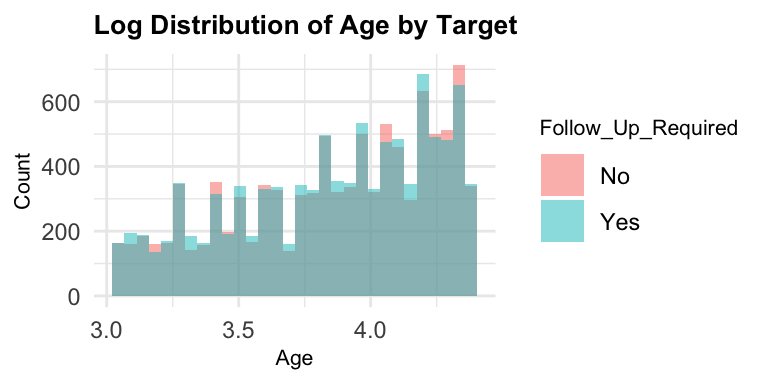

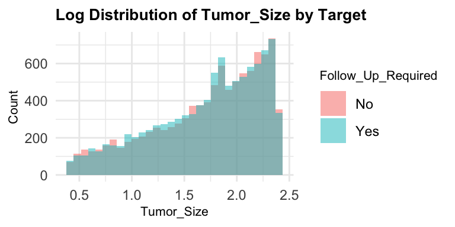

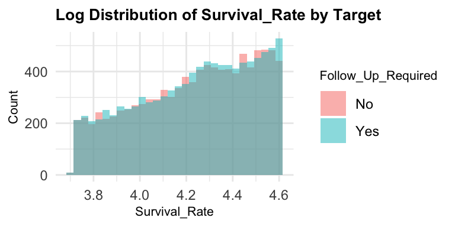

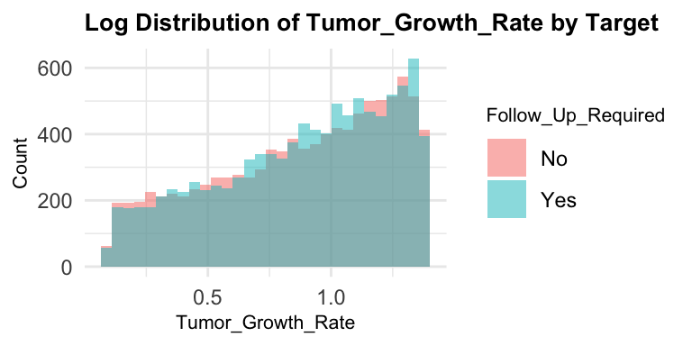

```r
log_df <- clean_df %>%
  mutate(across(all_of(numeric_feats), ~ log(.x + 1)))

numericDist(log_df, numeric_feats, target, "Log")
```

The log transformation did not improve the distribution of the numeric features. Instead, the data is now left skewed.

##### Square Root Transformation

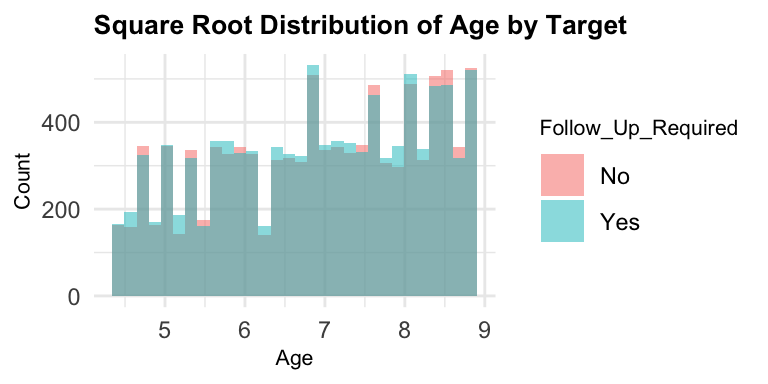

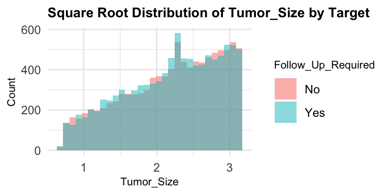

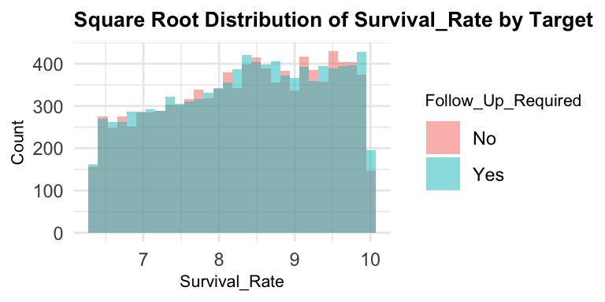

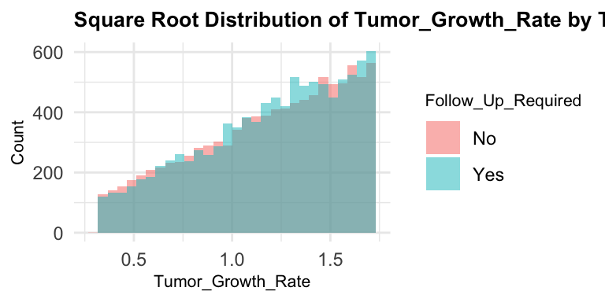

```r
sqrt_df <- clean_df %>%
  mutate(across(all_of(numeric_feats), ~ sqrt(.x)))

numericDist(sqrt_df, numeric_feats, target, "Square Root")
```

The square root transformation also did not improve the distribution of the numeric features. The data is also mostly left-skewed.

Both log and square root transformations failed to improve the distribution of the numeric features, instead creating left-skewed distributions. This confirms that the original data distributions are already well-suited for analysis. Since transformations did not provide any benefit and actually worsened the distribution characteristics, we will proceed with the original untransformed dataset for logistic regression modeling.

#### Scaling (kNN and Neural Networks)

kNN and neural networks work best when features are scaled to a similar range. kNN relies on distance calculations that can be skewed by features with different scales, while neural networks require scaled inputs for stable training. Since the numeric data follows a relatively uniform distribution, z-score standardization is appropriate to transform all features.

```r
# scale all features except target for kNN and neural network datasets
kNN_df <- clean_df %>%
  mutate(across(-Follow_Up_Required, ~ as.numeric(scale(.))))

nn_df <- nn_df %>%
  mutate(across(-Follow_Up_Required, ~ as.numeric(scale(.))))
```

## Data Splitting

Before training the models, the data must be split. Since my dataset is quite large with 20,000 observations, I plan to split the data into 3 parts: a training set (60%), a validation set (20%), and a test set (20%) . This split is ideal because it prevents data leakage and allows the final model to be tested on unseen data. The splitting of data will need to be done for the datasets prepared for Random Forest (`rf_df`), Logistic Regression (`clean_df`), kNN (`kNN_df`), and Neural Network (`nn_df`) models.

To create the splits, I used the `sample()` function to generate random indices for the training, validation, and test sets. This approach ensures that all four models are trained and evaluated on datasets with the same underlying observations, even though their features may be preprocessed differently.

```r
set.seed(2025)

# create training subset 60%
train_index <- sample(x = 1:nrow(df),
                      size = (round(nrow(df)*0.6,0)),
                      replace = F)

# create remaining indices (not in training set)
remaining_index <- setdiff(1:nrow(df), train_index)

# split the remaining 40% into validation and test sets
val_index <- sample(x = remaining_index,
                    size = (round(length(remaining_index)*0.5,0)),
                    replace = F)

# test set gets the remaining indices
test_index <- setdiff(remaining_index, val_index)
```

Furthermore, I used the following function to ensure that the training, validation, and test sets maintained the intended proportions of the original dataset (60:20:20).

```r
# split check
split_check <- function(train, val, test, orig, type){
  train_p <- round(nrow(train)/nrow(orig)*100)
  val_p <- round(nrow(val)/nrow(orig)*100)
  test_p <- round(nrow(test)/nrow(orig)*100)

  # Table for split with both counts and percentages
  split <- tibble(
    'Dataset' = c("Train", "Validation", "Test", "Total"),
    'Count' = c(nrow(train), nrow(val), nrow(test), nrow(orig)),
    'Percentage (%)' = c(train_p, val_p, test_p, 100)
  )

  kable(split, caption = paste0("Percentage of data for ", type, " splits")) %>%
    kable_styling()
}
```

### Random Forest

```r
# Random Forest
rf_train <- rf_df[train_index,]
rf_val <- rf_df[val_index,]
rf_test <- rf_df[test_index,]
split_check(rf_train, rf_val, rf_test, rf_df, "Random Forest")
```

Percentage of data for Random Forest splits

| Dataset | Count | Percentage (%) |
| --- | --- | --- |
| Train | 12000 | 60 |
| Validation | 4000 | 20 |
| Test | 4000 | 20 |
| Total | 20000 | 100 |

### Logistic Regression

```r
# Logistic Regression
LR_train <- clean_df[train_index,]
LR_val <- clean_df[val_index,]
LR_test <- clean_df[test_index,]
split_check(LR_train, LR_val, LR_test, clean_df, "Logistic Regression")
```

Percentage of data for Logistic Regression splits

| Dataset | Count | Percentage (%) |
| --- | --- | --- |
| Train | 12000 | 60 |
| Validation | 4000 | 20 |
| Test | 4000 | 20 |
| Total | 20000 | 100 |

### kNN

```r
# kNN
kNN_train <- kNN_df[train_index,]
kNN_val <- kNN_df[val_index,]
kNN_test <- kNN_df[test_index,]
split_check(kNN_train, kNN_val, kNN_test, kNN_df, "kNN")
```

Percentage of data for kNN splits

| Dataset | Count | Percentage (%) |
| --- | --- | --- |
| Train | 12000 | 60 |
| Validation | 4000 | 20 |
| Test | 4000 | 20 |
| Total | 20000 | 100 |

### Neural Network

```r
# Neural Networks
nn_train <- nn_df[train_index,]
nn_val <- nn_df[val_index,]
nn_test <- nn_df[test_index,]
split_check(nn_train, nn_val, nn_test, nn_df, "Neural Networks")
```

Percentage of data for Neural Networks splits

| Dataset | Count | Percentage (%) |
| --- | --- | --- |
| Train | 12000 | 60 |
| Validation | 4000 | 20 |
| Test | 4000 | 20 |
| Total | 20000 | 100 |

## Model Development

With the data properly split, the individual models—random forest, homogeneous logistic regression, homogeneous kNN, and homogeneous neural network—are trained using bagging and evaluated using k-fold cross-validation on the training set. Their predictions are then combined to build a heterogeneous ensemble, which is tuned and evaluated on the validation set using the holdout method. Finally, the fully tuned ensemble is assessed on the unseen test set to provide an unbiased estimate of its performance.

```r
# evaluation function
key_metrics <- function(predicted, actual){
  # Build confusion matrix
  confmat <- table(Predicted = predicted, Actual = actual)
  #        No/0   Yes/1
  # No/0
  # Yes/1

  # get values
  TN <- confmat[1,1]
  TP <- confmat[2,2]
  FN <- confmat[1,2]
  FP <- confmat[2,1]

  # calculate
  o_acc <- round((TP + TN)/sum(confmat),2)
  TPR <- round(TP / (TP + FN),2)  # Sensitivity
  TNR <- round(TN / (TN + FP),2) # Specificity
  Precision <- round(TP / (TP + FP),2)
  F1 <- round(2 * Precision * TPR / (Precision + TPR),2)


  # calculate accuracy, TPR, and TNR and display in table
  accuracy <- tibble(
    'Overall Accuracy' = o_acc,
    'True Positive Rate' = TPR,
    'True Negative Rate' = TNR,
    'Precision' = Precision,
    'F1-score' = F1
  )

  return(accuracy)
}
```

For k-fold cross validation, although the standard choice for k is 10, as the dataset is extremely large (20,000 overall observations, 12,000 observations for the training set), 10 folds would be computationally expensive. Instead, we will use a k of 5 for faster compution while allowing for reliable estimates.

### Random Forest

```r
k <- 5  # number of folds
n <- nrow(rf_train)  # total observations: 12000 obs
fold_indices <- sample(rep(1:k, length.out = n))  # indices for each fold (used for validation: ~2400 obs)

# initiate vector for storing accuracy: [0,0,0,0,0]
fold_acc <- numeric(k)
fold_tpr <- numeric(k)
fold_tnr <- numeric(k)
fold_fnr <- numeric(k)
fold_precision <- numeric(k)
fold_f1 <- numeric(k)

# k-fold CV loop
for (i in 1:k){
  # Create train and validation folds
  val_fold <- rf_train[fold_indices == i,]  # Rows where fold_indices equals i
  train_fold <- rf_train[fold_indices != i,]

  # Train Random Forest (default rtree = 500)
  rf_model <- randomForest(Follow_Up_Required ~ ., data = train_fold)

  # Make predictions and evaluate accuracy
  pprob <- predict(rf_model, val_fold, type = "prob")  # for soft-voting purposes
  predictions <- ifelse(pprob[,"Yes"] > 0.5, 1, 0)  # convert + class prob to class predictions with 0.5 threshold

  # Convert actual values to match prediction format
  actual_values <- ifelse(val_fold$Follow_Up_Required == "Yes", 1, 0)

  # store evaluation metrics
  metrics <- key_metrics(predictions, actual_values)
  fold_acc[i] <- metrics$`Overall Accuracy`
  fold_tpr[i] <- metrics$`True Positive Rate`
  fold_tnr[i] <- metrics$`True Negative Rate`
  fold_precision[i] <- metrics$`Precision`
  fold_f1[i] <- metrics$`F1-score`
}

# calculate average performance
# Calculate means
rf_cv_results <- tibble(
  'Overall Accuracy' = mean(fold_acc),
  'True Positive Rate' = mean(fold_tpr),
  'True Negative Rate' = mean(fold_tnr),
  'Precision' = mean(fold_precision),
  'F1-score' = mean(fold_f1)
)

kable(rf_cv_results, caption = "Key Metrics of the Random Forest Model") %>%
  kable_styling()
```

Key Metrics of the Random Forest Model

| Overall Accuracy | True Positive Rate | True Negative Rate | Precision | F1-score |
| --- | --- | --- | --- | --- |
| 0.498 | 0.55 | 0.45 | 0.504 | 0.524 |

As shown in the table above, the overall accuracy of the model is only 0.498. This is to be expected as the features are weakly correlated with the target. The sensitivity of the model is only 0.55, while the specificity is 0.45. Given the clinical importance of minimizing missed follow-ups, tuning will focus on improving sensitivity while monitoring precision and specificity to avoid excessive false positives.

#### Hyperparameter Tuning

To tune the model, we will use the `caret` package as it provides tools to assist with automated parameter tuning. First, we will set up a tuning grid for random forest training and evaluation using the mtry parameter, which defines how many features are randomly selected at each split in each decision tree. We will need to implement a custom summary function to obtain the key metric results that align with our evaluation framework.

```r
# Custom summary function that uses your key_metrics function
custom_summary <- function(data, lev = NULL, model = NULL) {
  # Determine positive class (typically the second level in caret)
  pos_class <- lev[2]

  # Convert probabilities to predictions using 0.5 threshold
  predictions <- ifelse(data[[pos_class]] > 0.5, 1, 0)

  # Convert actual values to match prediction format
  if (is.factor(data$obs)){
    actual_values <- ifelse(data$obs == pos_class, 1, 0)
  }else{
    actual_values <- data$obs
  }

  # Use your existing key_metrics function
  metrics_result <- key_metrics(predictions, actual_values)

  # Extract values and convert to named vector (caret requirement)
  result <- c(
    Accuracy = metrics_result$`Overall Accuracy`,
    Sensitivity = metrics_result$`True Positive Rate`,  # TPR
    Specificity = metrics_result$`True Negative Rate`,  # TNR
    Precision = metrics_result$`Precision`,
    F1 = metrics_result$`F1-score`
  )

  return(result)
}
```

```r
# Set up tuning grid
rf_grid <- expand.grid(mtry=c(2,4,8,16))

# Set CV control
ctrl <- trainControl(
  method = "cv",  # 5-fold cross-validation
  number = 5,  # Number of folds
  classProbs = TRUE,  # Generate class probabilities (needed for your custom_summary)
  summaryFunction = custom_summary,  # Your custom evaluation metrics
  savePredictions = "final"  # Save predictions from best model
)

# Model Training and Tuning
rf_tuned <- train(
  Follow_Up_Required ~ .,  # Formula: predict Follow_Up_Required using all other variables
  data = rf_train,  # Training dataset
  method = "rf",  # Random Forest algorithm
  tuneGrid = rf_grid,  # Parameter values to test
  trControl = ctrl,  # Cross-validation setup
  ntree = 500,  # Number of trees (fixed parameter)
  metric = "Sensitivity"  # Optimization metric (from your custom_summary)
)
```

```r
# extract results from the best mtry based on sensitivity
best_results <- rf_tuned$results[rf_tuned$results$mtry == rf_tuned$bestTune$mtry, ]

# Convert to match your manual format (percentages)
rf_tuned_results <- tibble(
  'Overall Accuracy' = round(best_results$Accuracy, 2),
  'True Positive Rate' = round(best_results$Sensitivity, 2),
  'True Negative Rate' = round(best_results$Specificity, 2),
  'Precision' = round(best_results$Precision, 2),
  'F1-score' = round(best_results$F1, 2)
)

kable(rf_tuned_results, caption = "Key Metrics of the Tuned Random Forest Model") %>%
  kable_styling()
```

Key Metrics of the Tuned Random Forest Model

| Overall Accuracy | True Positive Rate | True Negative Rate | Precision | F1-score |
| --- | --- | --- | --- | --- |
| 0.5 | 0.64 | 0.36 | 0.51 | 0.57 |

The Random Forest hyperparameter tuning was performed using sensitivity as the evaluation metric, prioritizing the detection of patients requiring follow-up over minimizing false positives. This clinical decision reflects the higher cost of missing patients who need care compared to unnecessary screening.

Furthermore, as this model will be used in a heterogeneous ensemble later on, extensive individual optimization is not necessary since ensemble methods can compensate for individual model weaknesses. The mediocre performance is worth noting, however, as this may impact the ensemble’s overall performance and suggest that a lower weight should be allocated to the Random Forest component during ensemble construction.

### Homogeneous Logistic Regression Ensemble

To build the homogeneous logistic regression ensemble we will apply bagging with 50 bootstrap samples, balancing performance gains and computational efficiency, since increasing the number of partitions beyond 50 yields diminishing returns. The model’s performance will be evaluated using k-fold cross-validation.

#### k-Fold Cross-Validation Training (with Bagging)

```r
k <- 5  # number of folds
n.partitions <- 50  # number of bootstrap samples for bagging
n <- nrow(LR_train)
folds <- sample(rep(1:k, length.out = n))
fold_results <- matrix(0, nrow = k, ncol = 5)  # Storage for metrics (Accuracy, TPR, TNR, Precision, F1)

all_probs <- c()  # store predicted probabilities for future ROC obs
all_actual <- c()  # store actual labels for ROC obs

for (i in 1:k) {
  val_fold <- LR_train[folds == i, ]
  train_fold <- LR_train[folds != i, ]

  # Initiate bagging predictions storage
  bagged_probs <- matrix(0, nrow = nrow(val_fold), ncol = n.partitions)

  for (b in 1:n.partitions){
    # Bootstrap sample
    train_sample <- train_fold[sample(1:nrow(train_fold), replace = T),]

    # Perform backward step-wise logisitic regression
    log_model <- glm(Follow_Up_Required ~., family=binomial(link='logit'), data=train_fold)

    # Predict
    bagged_probs[,b] <- predict(log_model, val_fold, type="response")
  }

  # average probability across boostrap models
  avg_prob <- rowMeans(bagged_probs)
  predictions <- ifelse(avg_prob > 0.5, 1, 0)

  # convert actual values for comparison/eval
  actual <- ifelse(val_fold$Follow_Up_Required == "Yes", 1, 0)

  # store avg probabilities and actual values for ROC curve (tuning purposes)
  all_probs <- c(all_probs, avg_prob)
  all_actual <- c(all_actual, actual)

  # Evaluate
  metrics <- key_metrics(predictions, actual)
  fold_results[i, ] <- as.numeric(metrics[1,])
}


colnames(fold_results) <- colnames(metrics)  # assign column names
logit_bagging_cv <- colMeans(fold_results)  # calculate average performance

# Display
kable(as.data.frame(t(logit_bagging_cv)),
      caption = "Key Metrics of the Homogeneous Logistic Regression Model") %>%
  kable_styling()
```

Key Metrics of the Homogeneous Logistic Regression Model

| Overall Accuracy | True Positive Rate | True Negative Rate | Precision | F1-score |
| --- | --- | --- | --- | --- |
| 0.5 | 0.65 | 0.344 | 0.506 | 0.57 |

From the table above, the homogeneous logistic regression ensemble achieved a relatively low overall accuracy of 0.5. The true positive rate (sensitivity) is decent at0.65, while the true negative rate (specificity) is substantially lower at 0.344. This indicates that the model correctly identified ~65% of patients requiring follow-up but misclassified a large proportion of patients who did not require follow-up. The precision of 0.506 suggests that only about half of the predicted follow_ups were correct, and the F1-score of 0.57 reflects the balance between sensitivity and precision. Given that correctly identifying patients needing follow-up is clinically more important than avoiding unnecessary recommendations, this trade-off—while not ideal—is acceptable for the current stage of modeling.

#### Hyperparameter Tuning

To reduce model complexity and retain only statistically significant predictors, we applied a backward stepwise elimination approach within each bootstrap sample, by implementing the function `stepwise_backwards()`.

```r
# stepwise function
stepwise_backwards <- function(data, target, threshold) {
  # Start with all predictors except the target
  predictors <- setdiff(names(data), target)

  repeat {
    # Fit logistic regression with current predictors
    formula <- as.formula(paste(target, "~", paste(predictors, collapse = " + ")))
    model <- glm(formula, family = binomial(link = "logit"), data = data)

    # Extract p-values (exclude intercept)
    p_values <- summary(model)$coefficients[-1, 4]

    # Check stopping condition
    max_p <- max(p_values)
    if (max_p <= threshold) break

    # Remove the variable with the highest p-value
    remove_var <- names(which.max(p_values))
    predictors <- predictors[predictors != remove_var]

    # Stop if no predictors left
    if (length(predictors) == 0) break
  }

  return(model)
}
```

```r
# Train function
final_stepwise_bagged <- function(train_data, n_bags=50){
  models <- list()

  for (b in 1:n_bags){
    # Bootstrap sample
    boot_sample <- train_data[sample(nrow(train_data), replace = TRUE), ]

    # Stepwise backward elimination
    model <- stepwise_backwards(boot_sample, "Follow_Up_Required", 0.05)
    models[[b]] <- model
  }
  return(models)

}

# Predict function
predict_stepwise_bagged <- function(models, new_data){
  predictions <- sapply(models, function(x){
    predict(x, new_data, type="response")
  })

  # Get average
  avg_probs <- rowMeans(predictions)
  return(avg_probs)
}


k <- 5  # number of folds
n.partitions <- 50  # number of bootstrap samples for bagging
n <- nrow(LR_train)
folds <- sample(rep(1:k, length.out = n))
fold_results <- matrix(0, nrow = k, ncol = 5)  # Storage for metrics (Accuracy, TPR, TNR, Precision, F1)

all_probs <- c()  # store predicted probabilities for future ROC obs
all_actual <- c()  # store actual labels for ROC obs

for (i in 1:k) {
  val_fold <- LR_train[folds == i, ]
  train_fold <- LR_train[folds != i, ]

  # implement train functions
  bagged_models <- final_stepwise_bagged(train_fold, n_bags = 50)

  # average probability across boostrap models
  avg_prob <- predict_stepwise_bagged(bagged_models, val_fold)  # implement predictor function
  predictions <- ifelse(avg_prob > 0.5, 1, 0)

  # convert actual values for comparison/eval
  actual <- ifelse(val_fold$Follow_Up_Required == "Yes", 1, 0)

  # store avg probabilities and actual values for ROC curve (tuning purposes)
  all_probs <- c(all_probs, avg_prob)
  all_actual <- c(all_actual, actual)

  # Evaluate
  metrics <- key_metrics(predictions, actual)
  fold_results[i, ] <- as.numeric(metrics[1,])
}


colnames(fold_results) <- colnames(metrics)  # assign column names
stepwise_LR_cv <- colMeans(fold_results)  # calculate average performance

# Display
kable(as.data.frame(t(stepwise_LR_cv)),
      caption = "Key Metrics of the Homogeneous Logistic Regression Model") %>%
  kable_styling()
```

Key Metrics of the Homogeneous Logistic Regression Model

| Overall Accuracy | True Positive Rate | True Negative Rate | Precision | F1-score |
| --- | --- | --- | --- | --- |
| 0.498 | 0.782 | 0.212 | 0.504 | 0.608 |

The stepwise backwards elimination improved the sensitivity to 0.782 but it reduced the specificity to 0.212. Therefore, we moved onto a second round of tuning by testing different thresholds to try and improve specificity while maintaining clinically acceptable sensitivity. We identified an optimal threshold using ROC analysis. Among thresholds with sensitivity >= 0.75, we selected the one that maximized specificity. This approach ensures fewer unnecessary follow-ups while preserving the ability to correctly identify most patients requiring follow-up.

```r
# ROC-based threshold optimization
roc_obj <- roc(all_actual, all_probs)
roc_data <- data.frame(
  threshold = roc_obj$thresholds,
  sensitivity = roc_obj$sensitivities,
  specificity = roc_obj$specificities
)

# Find optimal threshold (sensitivity >= 0.75, maximize specificity)
roc_filtered <- subset(roc_data, sensitivity >= 0.75)
best_threshold <- roc_filtered[which.max(roc_filtered$specificity), ]

# Apply optimal threshold
optimized_predictions <- ifelse(all_probs > best_threshold$threshold, 1, 0)
optimized_performance <- key_metrics(optimized_predictions, all_actual)

# Comparison table
comparison_results <- rbind(
  "Baseline (0.5)" = stepwise_LR_cv,
  "Optimized" = as.numeric(optimized_performance[1, ])
)

kable(comparison_results,
      caption = "Stepwise Logistic Regression: Baseline vs Threshold Optimization",
      digits = 3) %>%
  kable_styling()
```

Stepwise Logistic Regression: Baseline vs Threshold Optimization

|  | Overall Accuracy | True Positive Rate | True Negative Rate | Precision | F1-score |
| --- | --- | --- | --- | --- | --- |
| Baseline (0.5) | 0.498 | 0.782 | 0.212 | 0.504 | 0.608 |
| Optimized | 0.490 | 0.250 | 0.740 | 0.500 | 0.330 |

Among thresholds maintaining sensitivity ≥ 0.75, we selected the threshold (0.516) that maximized specificity (0.262). However, applying this optimized threshold resulted in a sensitivity of 0.25 and a specificity of 0.74, compared to the baseline performance of 0.782 sensitivity and 0.212 specificity.

#### Final Model Training

The final model will be trained using the full training set for the heterogeneous ensemble, which will be evaluated using the holdout method.

```r
# Train on full training set for ensemble
stepwise_ensemble_model <- final_stepwise_bagged(LR_train, n_bags = 50)
```

### Homogeneous kNN Ensemble

The following function will be used to train multiple kNN models on bootstrap samples of the training data and average the predicted probabilities.

```r
# kNN function using bagging
train_bagged_knn_predict <- function(train_data, test_data, optimal_k, n.partitions = 50) {
  # Separate features and labels
  trainX_all <- train_data[, !names(train_data) %in% "Follow_Up_Required"]
  testX <- test_data[, !names(test_data) %in% "Follow_Up_Required"]

  # Prepare storage for bagged predictions
  bagged_probs <- matrix(0, nrow = nrow(test_data), ncol = n.partitions)

  for (b in 1:n.partitions) {
    # Bootstrap sample from full training data
    train_sample <- train_data[sample(1:nrow(train_data), replace = TRUE), ]

    trainX <- train_sample[, !names(train_sample) %in% "Follow_Up_Required"]
    trainY <- as.numeric(train_sample$Follow_Up_Required == "Yes")

    # Predict probabilities
    knn_prob <- knn.reg(train = trainX,
                        test = testX,
                        y = trainY,
                        k = optimal_k)

    bagged_probs[, b] <- knn_prob$pred
  }

  # Average the predicted probabilities across bootstrap models
  avg_probs <- rowMeans(bagged_probs)

  return(avg_probs)
}
```

#### k-Fold Cross-Validation Training (with Bagging)

To train the homogeneous kNN ensemble, we initialized kNN with k=5 as a balance between bias and variance. Small k values (k=1,3) risk overfitting to noise, while large k values may over-smooth decision boundaries. The k=5 starting point allows for local pattern detection while maintaining computational efficiency. Although the square root rule would suggest k ≈ $\sqrt(12000) ≈ 109$, such large k values are impractical and would likely over-smooth patterns in our dataset.

```r
# Perform kfold-CV eval on bagged kNN ensemble using the functions above
k <- 5  # number of folds
n.partitions <- 50  # number of bootstrap samples for bagging
n <- nrow(kNN_train)  # your kNN dataset
folds <- sample(rep(1:k, length.out = n))
fold_results <- matrix(0, nrow = k, ncol = 5)  # Storage for metrics

optimal_k <- 5

for (i in 1:k) {
  val_fold <- kNN_train[folds == i, ]
  train_fold <- kNN_train[folds != i, ]

  # Initiate bagging predictions storage
  bagged_probs <- matrix(0, nrow = nrow(val_fold), ncol = n.partitions)



  # calculate avg prob
  avg_prob <- train_bagged_knn_predict(train_fold, val_fold, optimal_k, n.partitions = 50)
  predictions <- ifelse(avg_prob > 0.5, 1, 0)

  # Convert actual values for comparison/evaluation
  actual <- ifelse(val_fold$Follow_Up_Required == "Yes", 1, 0)

  # Evaluate using your key_metrics function
  metrics <- key_metrics(predictions, actual)
  fold_results[i, ] <- as.numeric(metrics[1, ])
}

# calculate average performance
colnames(fold_results) <- colnames(metrics)
knn_bagging_cv <- colMeans(fold_results)

# Display
kable(as.data.frame(t(knn_bagging_cv)),
      caption = "Key Metrics of the Homogeneous kNN Model") %>%
  kable_styling()
```

Key Metrics of the Homogeneous kNN Model

| Overall Accuracy | True Positive Rate | True Negative Rate | Precision | F1-score |
| --- | --- | --- | --- | --- |
| 0.5 | 0.53 | 0.468 | 0.506 | 0.514 |

The homogeneous kNN ensemble achieved a sensitivity of 0.53 and specificity of 0.468. Given the clinical importance of maximizing sensitivity in follow-up screening, we investigated various k-values to potentially improve the model’s ability to correctly identify patients requiring follow-up.

#### Hyperparameter Tuning

To tune the bagged kNN ensemble, we will first use the `caret` package to identify the optimal number of neighbors (k), similar to our approach for the Random Forest model. We will evaluate k values of 11, 15, 25, 55, 109. This range provides a balance between exploring different neighborhood sizes and allows us to see the performance of the square root ruled k. Using `caret` allows for computational efficiency, given that bagging combined with k-fold cross-validation is already computationally intensive.

```r
# Tune k using caret and the same ctrl as random forest
# set grid
knn_grid <- expand.grid(k = c(11,15,25,55, 109))
knn_tuned <- train(Follow_Up_Required ~ .,
                   data = kNN_train,
                   method = "knn",
                   tuneGrid = knn_grid,
                   trControl = ctrl,
                   metric = "Sensitivity",
                   preProcess = c("center", "scale"))
optimal_k <- knn_tuned$bestTune$k
```

```r
# extract results
knn_all <- knn_tuned$results

# Convert to match your manual format (percentages)
knn_tuned_results <- tibble(
  k = knn_all$k,
  'Overall Accuracy' = round(knn_all$Accuracy, 2),
  'True Positive Rate' = round(knn_all$Sensitivity, 2),
  'True Negative Rate' = round(knn_all$Specificity, 2),
  'Precision' = round(knn_all$Precision, 2),
  'F1-score' = round(knn_all$F1, 2)
)

kable(knn_tuned_results, caption = "Key Metrics of the Tuned kNN Model") %>%
  kable_styling()
```

Key Metrics of the Tuned kNN Model

| k | Overall Accuracy | True Positive Rate | True Negative Rate | Precision | F1-score |
| --- | --- | --- | --- | --- | --- |
| 11 | 0.50 | 0.53 | 0.46 | 0.50 | 0.51 |
| 15 | 0.50 | 0.53 | 0.46 | 0.50 | 0.51 |
| 25 | 0.49 | 0.54 | 0.45 | 0.50 | 0.52 |
| 55 | 0.49 | 0.56 | 0.43 | 0.50 | 0.53 |
| 109 | 0.50 | 0.60 | 0.41 | 0.51 | 0.55 |

From the table above, we can see that although the k-value of 109 has the largest sensitivity, it is not much better than the smaller k value of 55. For the final model, we will use the k value of 55 because the sensitivity is still highly sensitive but is slightly more balanced with a slightly higher specificity.

#### Final Model Training

Since the kNN function I created both trains and predicts, I will be implementing the following code inside the ensemble: `kNN_probs <- train_bagged_knn_predict(kNN_train, kNN_val, optimal_k = 55, n.partitions = 50)`

### Homogeneous Neural Network Ensemble

#### k-Fold Cross-Validation Training (with Bagging)

To train the bagged Neural Network ensemble, we will use the functions I above. As neural networks are computationally expensive, we will use the default parameters of the `nnet()` function, which performs faster than `neuralnet()`.

```r
k <- 5
n_bags <- 50
n <- nrow(nn_train)
folds <- sample(rep(1:k, length.out = n))
fold_results <- matrix(0, nrow = k, ncol = 5)

for (i in 1:k) {
  # Split data into training and validation folds
  val_fold <- nn_train[folds == i, ]
  train_fold <- nn_train[folds != i, ]

  # Train bagged neural network ensemble
  models <- list()
  for (b in 1:n_bags) {
    # Bootstrap sample from training fold
    boot_sample <- train_fold[sample(nrow(train_fold), replace = TRUE), ]

    # Train individual neural network
    model <- nnet(Follow_Up_Required ~ .,
                 data = boot_sample,
                 size = 1,
                 trace = FALSE)

    models[[b]] <- model
  }

  # Make predictions on validation fold
  # Get predictions from all models
  all_predictions <- matrix(0, nrow = nrow(val_fold), ncol = n_bags)
  for (b in 1:n_bags) {
    all_predictions[, b] <- predict(models[[b]], val_fold, type = "raw")
  }

  # Average predictions across all models
  avg_prob <- rowMeans(all_predictions)
  predictions <- ifelse(avg_prob > 0.5, 1, 0)
  actual <- ifelse(val_fold$Follow_Up_Required == "Yes", 1, 0)

  # Ensure both classes are present for proper confusion matrix
  predictions <- factor(predictions, levels = c(0, 1))
  actual <- factor(actual, levels = c(0, 1))

  # Calculate metrics for this fold
  metrics <- key_metrics(predictions, actual)
  fold_results[i, ] <- as.numeric(metrics[1, ])
}

# Calculate average performance across all folds
colnames(fold_results) <- colnames(metrics)
nn_bagging_cv <- colMeans(fold_results)

# Display results
kable(as.data.frame(t(nn_bagging_cv)),
      caption = "Key Metrics of the Bagged Neural Network Model") %>%
  kable_styling()
```

Key Metrics of the Bagged Neural Network Model

| Overall Accuracy | True Positive Rate | True Negative Rate | Precision | F1-score |
| --- | --- | --- | --- | --- |
| 0.36 | NaN | 0.36 | 0 | NaN |

The Neural Network model was unable to properly predict the target. This is likely due to the poor feature-target correlation we observed in the correlation analysis. As such, we will not include the Neural Network model in the heterogeneous ensemble.

### Ensemble

The ensemble will be trained with the complete training sets and tested using the validation set. A final comparison will be done for the individual and ensemble models using the test set.

#### Training

```r
# function to train ensemble
ensemble <- function(rf_model, logR_model, rf_test, logR_test, knn_train, knn_test, weights = c(1/3, 1/3, 1/3)){
  # Predict probabilities for each class
  rf_probs <- predict(rf_model, rf_test, type = "prob")[,'Yes']
  lr_probs <- predict_stepwise_bagged(logR_model, logR_test)
  knn_probs <- train_bagged_knn_predict(knn_train, knn_test, optimal_k = 55, n.partitions = 50)

  # Combine into a matrix to calculate row-wise mean
  ## we only want the positive class of the rf prediction
  ensemble_probs <- weights[1] * rf_probs +
                   weights[2] * lr_probs +
                   weights[3] * knn_probs

  return(list(
    ensemble_probs = ensemble_probs,
    rf_probs = rf_probs,
    lr_probs = lr_probs,
    knn_probs = knn_probs
  ))
}

ensemble_results <- ensemble(
  rf_model = rf_tuned,
  logR_model = stepwise_ensemble_model,
  rf_test = rf_val,
  logR_test = LR_val,
  knn_train = kNN_train,
  knn_test = kNN_val,
  weights = c(1/3, 1/3, 1/3)  # Equal weights
)
```

#### Performance Evaluation

```r
evaluate_ensemble <- function(ensemble_results, validation_data, threshold = 0.5) {
  actual <- ifelse(validation_data$Follow_Up_Required == "Yes", 1, 0)

  # Evaluate each model
  models_to_eval <- list(
    "Random_Forest" = ensemble_results$rf_probs,
    "Logistic_Regression" = ensemble_results$lr_probs,
    "kNN" = ensemble_results$knn_probs,
    "Ensemble" = ensemble_results$ensemble_probs
  )

  # Initialize results list
  results_list <- list()

  # Evaluate models and store metrics
  for (i in 1:length(models_to_eval)) {
    probs <- models_to_eval[[i]]
    predictions <- ifelse(probs > threshold, 1, 0)

    # Keep as numeric for key_metrics function
    predictions_numeric <- as.numeric(predictions)
    actual_numeric <- as.numeric(actual)

    # Calculate metrics
    metrics <- key_metrics(predictions_numeric, actual_numeric)

    # Store metrics with model name
    model_results <- cbind(Model = names(models_to_eval)[i], metrics)
    results_list[[i]] <- model_results
  }

  # Combine all results
  results <- bind_rows(results_list)

  return(results)
}

# evaluate the ensemble
results <- evaluate_ensemble(ensemble_results, rf_val)
kable(results, row.names = F) %>% kable_styling()
```

| Model | Overall Accuracy | True Positive Rate | True Negative Rate | Precision | F1-score |
| --- | --- | --- | --- | --- | --- |
| Random_Forest | 0.50 | 0.62 | 0.39 | 0.50 | 0.55 |
| Logistic_Regression | 0.51 | 0.82 | 0.20 | 0.50 | 0.62 |
| kNN | 0.51 | 0.58 | 0.43 | 0.50 | 0.54 |
| Ensemble | 0.51 | 0.66 | 0.37 | 0.51 | 0.58 |

#### Tuning

To improve the ensemble performance, we will tune the model by adjusting the weights of individual components. While the Logistic Regression model achieved the highest sensitivity, which is crucial for medical screening, the current ensemble sensitivity falls short of this individual performance. To address this, we will assign weights that prioritize the Logistic Regression model while leveraging kNN’s superior specificity to reduce unnecessary follow-up appointments.

The proposed weights are: Random Forest = 0.1, Logistic Regression = 0.7, and kNN = 0.20. This weighting strategy gives the highest weight to Logistic Regression to maintain high sensitivity, while assigning substantial weight to kNN to improve specificity and reduce false positives. The goal is to get the sensitivity to at least 0.75, while maintaining a decent specificity.

```r
tune_weights <- c(0.1, 0.7, 0.2)

tuned_ensemble_results <- ensemble(
  rf_model = rf_tuned,
  logR_model = stepwise_ensemble_model,
  rf_test = rf_val,
  logR_test = LR_val,
  knn_train = kNN_train,
  knn_test = kNN_val,
  weights = tune_weights
)

# evaluate the ensemble
tuned_results <- evaluate_ensemble(tuned_ensemble_results, rf_val)
kable(tuned_results, row.names = F) %>% kable_styling()
```

| Model | Overall Accuracy | True Positive Rate | True Negative Rate | Precision | F1-score |
| --- | --- | --- | --- | --- | --- |
| Random_Forest | 0.50 | 0.62 | 0.39 | 0.5 | 0.55 |
| Logistic_Regression | 0.51 | 0.82 | 0.20 | 0.5 | 0.62 |
| kNN | 0.50 | 0.57 | 0.44 | 0.5 | 0.53 |
| Ensemble | 0.51 | 0.73 | 0.30 | 0.5 | 0.59 |

Although the sensitivity did not reach the target of 0.75, it improved from 0.66 to 0.73 with optimized weights. The ensemble achieves a reasonable balance between sensitivity and specificity, outperforming the equal-weighted baseline. As such, we will proceed with these tuning parameters for final evaluation using the reserved test set.

## Final Evaluation

```r
# Generate final test predictions
final_test_results <- ensemble(
  rf_model = rf_tuned,
  logR_model = stepwise_ensemble_model,
  rf_test = rf_test,
  logR_test = LR_test,
  knn_train = kNN_train,
  knn_test = kNN_test,
  weights = tune_weights
)

# Evaluate final performance
final_performance <- evaluate_ensemble(final_test_results, rf_test)
kable(tuned_results, row.names = F) %>% kable_styling()
```

| Model | Overall Accuracy | True Positive Rate | True Negative Rate | Precision | F1-score |
| --- | --- | --- | --- | --- | --- |
| Random_Forest | 0.50 | 0.62 | 0.39 | 0.5 | 0.55 |
| Logistic_Regression | 0.51 | 0.82 | 0.20 | 0.5 | 0.62 |
| kNN | 0.50 | 0.57 | 0.44 | 0.5 | 0.53 |
| Ensemble | 0.51 | 0.73 | 0.30 | 0.5 | 0.59 |

The modest overall performance reflects the fundamental challenge identified in our exploratory analysis: weak feature-outcome correlations. Despite these constraints, the ensemble approach successfully prioritizes sensitivity—the most critical aspect for medical screening where missing patients requiring follow-up has serious clinical consequences.

It is important to note that the implementation of k-fold cross-validation on bagged models is computationally expensive, requiring substantial processing time for comprehensive model evaluation. However, this methodological rigor ensures robust performance estimates and proper model validation, which is essential for clinical applications where model reliability is paramount.

## References

Arif Miah. (March 2025). [*Brain Tumor Dataset*](https://www.kaggle.com/datasets/miadul/brain-tumor-dataset), Version 1.  
Lantz, B. (2019). Machine Learning with R : Expert Techniques for Predictive Modeling (Third). Packt Publishing, Limited, . Â.